# Using the GSODR Package

Adam H. Sparks

2016-10-10

# Introduction

An R package that provides a function that automates downloading and cleaning data from the “[Global Surface Summary of the Day (GSOD)](https://data.noaa.gov/dataset/global-surface-summary-of-the-day-gsod)” data provided by the US National Climatic Data Center (NCDC). Stations are individually checked for number of missing days to assure data quality, those stations with too many missing observations as defined by the user are omitted. All units are converted to International System of Units (SI), e.g., inches to millimetres and Fahrenheit to Celsius. Output is saved as a Comma Separated Value (CSV) file or in a spatial GeoPackage (GPKG) file, implemented by most major GIS software, summarising each year by station, which also includes vapour pressure and relative humidity variables calculated from existing data in GSOD.

This package was largely based on Tomislav Hengl’s work, getGSOD.R in “[A Practical Guide to Geostatistical Mapping](http://spatial-analyst.net)”, with updates for speed, cross-platform functionality, and more options for data retrieval and error correction.

For more information see the description of the data provided by NCDC, http://www7.ncdc.noaa.gov/CDO/GSOD_DESC.txt.

# Using the package

## Load GSODR

```r
library(GSODR)
stations <- GSODR::GSOD_stations
```

## Plot Global Station Locations

GSODR provides a cleaned list of station locations with the package. Stations are omitted if they do not provide a valid longitude or latitude value. See fetch_isd-history.md for details on the criteria and how this list is generated and last updated.

Using this data we can plot the station locations that are included in GSOD that provide valid geo-locations.

Using ggplot2 and the ggalt package it is possible to plot the station locations using alpha transparency to see the densest part of the network and use the Robinson projection for the map.

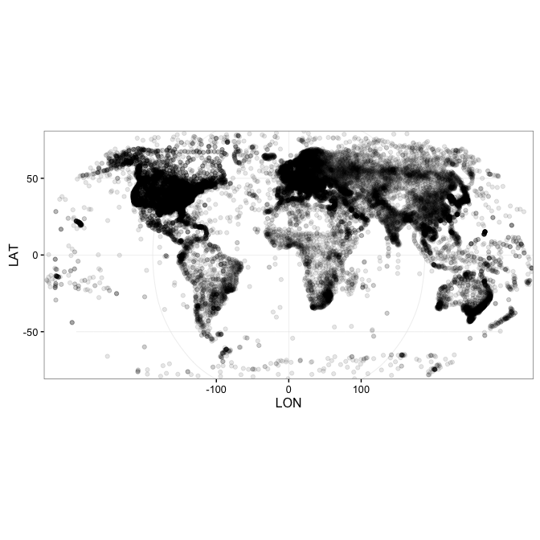

GSOD Station Locations

```r
library(ggplot2)
library(ggalt)

ggplot(stations, aes(x = LON, y = LAT)) +
  geom_point(alpha = 0.1) +
  coord_proj("+proj=robin +lon_0=0 +x_0=0 +y_0=0 +ellps=WGS84 +datum=WGS84 +units=m +no_defs") +
  theme_bw()
```

## Find Stations in Australia

GSODR provides lists of weather station locations and elevation values. Using dplyr, we can find all the stations in Australia.

```r
library(dplyr)
# left_join the the station data with the country list
station_locations <- left_join(stations, GSODR::GSOD_country_list, by = c("CTRY" = "FIPS"))

# create data.frame for Australia only
Oz <- filter(station_locations, COUNTRY_NAME == "AUSTRALIA")
head(Oz)
```

```
##     USAF  WBAN                  STN_NAME CTRY STATE CALL     LAT     LON
## 1 695023 99999       HORN ISLAND   (HID)   AS  <NA> KQXC -10.583 142.300
## 2 749430 99999        AIDELAIDE RIVER SE   AS  <NA> <NA> -13.300 131.133
## 3 749432 99999 BATCHELOR FIELD AUSTRALIA   AS  <NA> <NA> -13.049 131.066
## 4 749438 99999      IRON RANGE AUSTRALIA   AS  <NA> <NA> -12.700 143.300
## 5 749439 99999  MAREEBA AS/HOEVETT FIELD   AS  <NA> <NA> -17.050 145.400
## 6 749440 99999                 REID EAST   AS  <NA> <NA> -19.767 146.850
##   ELEV_M    BEGIN      END        STNID ELEV_M_SRTM_90m COUNTRY_NAME iso2c
## 1     NA 19420804 20030816 695023-99999              24    AUSTRALIA    AU
## 2    131 19430228 19440821 749430-99999              96    AUSTRALIA    AU
## 3    107 19421231 19430610 749432-99999              83    AUSTRALIA    AU
## 4     18 19420917 19440930 749438-99999              63    AUSTRALIA    AU
## 5    443 19420630 19440630 749439-99999             449    AUSTRALIA    AU
## 6    122 19421012 19430405 749440-99999              75    AUSTRALIA    AU
##   iso3c
## 1   AUS
## 2   AUS
## 3   AUS
## 4   AUS
## 5   AUS
## 6   AUS
```

```r
# find a station in Toowoomba, Queensland
filter(Oz, STN_NAME == "TOOWOOMBA")
```

```
##     USAF  WBAN  STN_NAME CTRY STATE CALL     LAT     LON ELEV_M    BEGIN
## 1 945510 99999 TOOWOOMBA   AS  <NA> <NA> -27.583 151.933    676 19561231
##        END        STNID ELEV_M_SRTM_90m COUNTRY_NAME iso2c iso3c
## 1 20120503 945510-99999             670    AUSTRALIA    AU   AUS
```

Year

Download weather data from the station Toowoomba, Queensland, Australia for 2010 and save it in the user’s home directory using the STNID in the `station` parameter of `get_GSOD()`.

```r
get_GSOD(years = 2010, station = "955510-99999", dsn = "~/",
         filename = "Toowoomba_Airport")
```

```
##
## Finished downloading file. Parsing the station file(s) now.
```

```
##
## Finished parsing files. Writing files to disk now.
```

## Find Stations Within a Specified Distance of a Point

Using the `nearest_stations()` function, you can find stations closest to a given point specified by latitude and longitude in decimal degrees. This can be used to generate a vector to pass along to `get_GSOD()` and download the stations of interest.

There are missing stations in this query. Not all that are listed and queried actually have files on the server.

```r
tbar_stations <- nearest_stations(LAT = -27.5598, LON = 151.9507, distance = 50)
```

```
##      USAF  WBAN                        STN_NAME CTRY STATE CALL     LAT
## 1: 945510 99999                       TOOWOOMBA   AS    NA   NA -27.583
## 2: 945520 99999                           OAKEY   AS    NA YBOK -27.411
## 3: 945620 99999 UNIVERSITY OF QUEENSLAND GATTON   AS    NA   NA -27.550
## 4: 949999 00170                  GATTON (LAWES)   AS    NA   NA -27.550
## 5: 949999 00183      GATTONDPI RESEARCH STATION   AS    NA   NA -27.530
## 6: 955510 99999               TOOWOOMBA AIRPORT   AS    NA   NA -27.550
##        LON ELEV_M    BEGIN      END        STNID ELEV_M_SRTM_90m
## 1: 151.933  676.0 19561231 20120503 945510-99999             670
## 2: 151.735  406.9 19730430 20161002 945520-99999             404
## 3: 152.333   94.0 20030330 20161002 945620-99999              90
## 4: 152.330   29.0 19711231 19840429 949999-00170              92
## 5: 152.330   95.0 19831130 19840629 949999-00183              88
## 6: 151.917  642.0 19980301 20161002 955510-99999             635
```

```r
tbar_stations <- tbar_stations$STNID

get_GSOD(years = 2010, station = tbar_stations, dsn = "~/",
         filename = "Toowoomba_50km_2010")
```

```
##
## Finished downloading file. Parsing the indivdual station files now.
```

```
##
## Finished parsing files. Writing files to disk now.
```

If you wished to drop the stations, 949999-00170 and 949999-00183 from the query, you could do this.

```r
remove <- c("949999-00170", "949999-00183")
tbar_stations <- tbar_stations[!tbar_stations %in% remove]

get_GSOD(years = 2010, station = tbar_stations, dsn = "~/",
         filename = "Toowoomba_50km")
```

## Plot Maximum and Miniumum Temperature Values

Using the first data downloaded for a single station, plot the temperature for 2010, setting the “-9999” value to NA on import using `read_csv` from Hadley’s `readr` package.

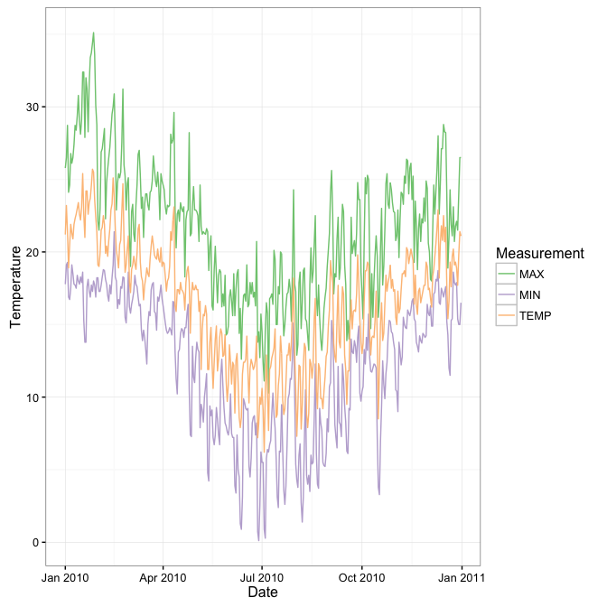

Toowoomba 2010 Temperatures

```r
library(lubridate)
library(readr)
library(tidyr)

# Import the data for Toowoomba previously downloaded and cleaned
tbar <- read_csv("~/Toowoomba_Airport-2010.csv", na = "-9999")

# Create a dataframe of just the date and temperature values that we want to plot
tbar_temps <- tbar[, c(14, 19, 33, 35)]

# Gather the data from wide to long
tbar_temps <- gather(tbar_temps, Measurement, gather_cols = TEMP:MIN)

ggplot(data = tbar_temps, aes(x = ymd(YEARMODA), y = value,
                              colour = Measurement)) +
  geom_line() +
  scale_color_brewer(type = "qual", na.value = "black") +
  scale_y_continuous(name = "Temperature") +
  scale_x_date(name = "Date") +
  theme_bw()
```

### Fetching the latest station list from NCDC

A list of stations is provided with the GSODR package for convince and speed. However, the original list is updated somewhat regularly by the NCDC. If you would like to use the very latest station list, you may do so by using the `refresh` parameter in `get_GSOD()`. This list will only be available for the R session in which you have specified the option to refresh the station list and downloaded data, it will not overwrite the default list available with the package.

```r
get_GSOD(years = 2016, dsn = "~/", filename = "newest_stations", refresh = TRUE)
```

## Creating spatial files

Because the stations provide geospatial location information, it is possible to create a spatial file. [GeoPackage files](http://www.geopackage.org) are a open, standards-based, platform-independent, portable, self-describing compact format for transferring geospatial information, which handle vector files much like shapefiles do, but eliminate many of the issues that shapefiles have with field names and the number of files. The `get_GSOD()` function can create a GeoPackage file, which can be used with a GIS for further analysis and mapping with other spatial objects.

```r
get_GSOD(years = 2015, country = "Australia", dsn = "~/", filename = "AUS",
         CSV = FALSE, GPKG = TRUE)
```

Importing the GeoPackage file can be a bit tricky. The dsn will be the full path along with the file name. The layer to be specified is “GSOD”, this is specified in the `get_GSOD()` function and will not change. The file name, specified in the dsn will, but the layer name will not.

```r
library(rgdal)
AUS_stations <- readOGR(dsn = path.expand("~/AUS-2015.gpkg"), layer = "GSOD")
class(AUS_stations)
```

```
## [1] "SpatialPointsDataFrame"
## attr(,"package")
## [1] "sp"
```

```r
print(unique(AUS_stations$STN_NAME))
```

```
##   [1] WOLFSEGG
##   [2] STIFT ZWETTL
##   [3] JAUERLING
##   [4] WIEN/INNERE STADT
##   [5] LINZ/STADT
##   [6] WIEN/MARIABRUNN
##   [7] ZWERNDORF-MARCHEGG
##   [8] FELDKIRCH
##   [9] LANDECK
##  [10] ALPINZENTRUM RUDOLFSHUETTE
##  [11] SALZBURG
##  [12] GMUNDEN
##  [13] BRUCK/MUR
##  [14] WIENER NEUSTADT
##  [15] KLEINZICKEN
```

[output cut: 132 more lines]

Since GeoPackage files are formatted as SQLite databases you can use the existing R tools for SQLite files [(J. Stachelek 2016)](https://jsta.github.io/2016/07/14/geopackage-r.html). One easy way is using dplyr, which we’ve already used to filter the stations.

This option is much faster to load since it does not load the geometry.

```r
AUS_sqlite <- tbl(src_sqlite(path.expand("~/AUS-2015.gpkg")), "GSOD")
class(AUS_sqlite)
```

```
## [1] "tbl_sqlite" "tbl_sql"    "tbl_lazy"   "tbl"
```

```r
print(AUS_sqlite, n = 5)
```

```
## Source:   query [?? x 48]
## Database: sqlite 3.8.6 [/Users/U8004755/AUS-2015.gpkg]
##
##     fid       geom   USAF  WBAN        STNID STN_NAME  CTRY STATE  CALL
##   <int>     <list>  <chr> <chr>        <chr>    <chr> <chr> <chr> <chr>
## 1     1 <raw [29]> 110010 99999 110010-99999 WOLFSEGG    AU -9999 -9999
## 2     2 <raw [29]> 110010 99999 110010-99999 WOLFSEGG    AU -9999 -9999
## 3     3 <raw [29]> 110010 99999 110010-99999 WOLFSEGG    AU -9999 -9999
## 4     4 <raw [29]> 110010 99999 110010-99999 WOLFSEGG    AU -9999 -9999
## 5     5 <raw [29]> 110010 99999 110010-99999 WOLFSEGG    AU -9999 -9999
## # ... with more rows, and 39 more variables: ELEV_M <dbl>,
## #   ELEV_M_SRTM_90m <dbl>, BEGIN <dbl>, END <dbl>, YEARMODA <chr>,
## #   YEAR <chr>, MONTH <chr>, DAY <chr>, YDAY <dbl>, TEMP <dbl>,
## #   TEMP_CNT <int>, DEWP <dbl>, DEWP_CNT <int>, SLP <dbl>, SLP_CNT <int>,
## #   STP <dbl>, STP_CNT <int>, VISIB <dbl>, VISIB_CNT <int>, WDSP <dbl>,
## #   WDSP_CNT <int>, MXSPD <dbl>, GUST <dbl>, MAX <dbl>, MAX_FLAG <chr>,
## #   MIN <dbl>, MIN_FLAG <chr>, PRCP <dbl>, PRCP_FLAG <chr>, SNDP <dbl>,
## #   I_FOG <int>, I_RAIN_DRIZZLE <int>, I_SNOW_ICE <int>, I_HAIL <int>,
## #   I_THUNDER <int>, I_TORNADO_FUNNEL <int>, EA <dbl>, ES <dbl>, RH <dbl>
```

# Generating hourly temperature data from daily using the `chillR` package

The `chillR` package from [Eike Luedeling](http://eikeluedeling.com/index.html) has a function, `make_hourly_temps()` that can be used to temporally downscale daily weather data to hourly using the station’s latitude. Here’s how that’s possible using the Toowoomba-Airport data.

To use this function it is necessary to rename the MAX, MIN, YEAR and YDAY columns and convert the `tibble` to a standard `data.frame` object so that `make_hourly_temps()` will recognize the columns and can operate on the data.

```r
library(chillR)
# rename columns and convert the object to a standard data.frame
colnames(tbar)[colnames(tbar) == "MAX"] <- "Tmax"
colnames(tbar)[colnames(tbar) == "MIN"] <- "Tmin"
colnames(tbar)[colnames(tbar) == "YEAR"] <- "Year"
colnames(tbar)[colnames(tbar) == "YDAY"] <- "JDay"
tbar <- as.data.frame(tbar)

# generate hourly temperature values
tbar <- make_hourly_temps(tbar[, 8], tbar)

head(tbar)
```

```
##     USAF  WBAN        STNID          STN_NAME CTRY STATE CALL    LAT
## 1 955510 99999 955510-99999 TOOWOOMBA AIRPORT   AS  <NA> <NA> -27.55
## 2 955510 99999 955510-99999 TOOWOOMBA AIRPORT   AS  <NA> <NA> -27.55
## 3 955510 99999 955510-99999 TOOWOOMBA AIRPORT   AS  <NA> <NA> -27.55
## 4 955510 99999 955510-99999 TOOWOOMBA AIRPORT   AS  <NA> <NA> -27.55
## 5 955510 99999 955510-99999 TOOWOOMBA AIRPORT   AS  <NA> <NA> -27.55
## 6 955510 99999 955510-99999 TOOWOOMBA AIRPORT   AS  <NA> <NA> -27.55
##       LON ELEV_M ELEV_M_SRTM_90m    BEGIN      END YEARMODA Year MONTH DAY
## 1 151.917    642             635 19980301 20161002 20100101 2010    01  01
## 2 151.917    642             635 19980301 20161002 20100102 2010    01  02
## 3 151.917    642             635 19980301 20161002 20100103 2010    01  03
## 4 151.917    642             635 19980301 20161002 20100104 2010    01  04
## 5 151.917    642             635 19980301 20161002 20100105 2010    01  05
## 6 151.917    642             635 19980301 20161002 20100106 2010    01  06
##   JDay TEMP TEMP_CNT DEWP DEWP_CNT    SLP SLP_CNT   STP STP_CNT   VISIB
```

[output cut: 48 more lines]

# Notes

## Elevation Values

90 metre (90m) hole-filled SRTM digital elevation (Jarvis *et al.* 2008) was used to identify and correct/remove elevation errors in data for station locations between -60˚ and 60˚ latitude. This applies to cases here where elevation was missing in the reported values as well. In case the station reported an elevation and the DEM does not, the station reported is taken. For stations beyond -60˚ and 60˚ latitude, the values are station reported values in every instance. See https://github.com/adamhsparks/GSODR/blob/devel/data-raw/fetch_isd-history.md for more detail on the correction methods.

## WMO Resolution 40. NOAA Policy

*Users of these data should take into account the following (from the [NCDC website](http://www7.ncdc.noaa.gov/CDO/cdoselect.cmd?datasetabbv=GSOD&countryabbv=&georegionabbv=)):*

> “The following data and products may have conditions placed on their international commercial use. They can be used within the U.S. or for non-commercial international activities without restriction. The non-U.S. data cannot be redistributed for commercial purposes. Re-distribution of these data by others must provide this same notification.” [WMO Resolution 40. NOAA Policy](http://www.wmo.int/pages/about/Resolution40.html)

# References

Stachelek, J. 2016. Using the Geopackage Format with R. URL: https://jsta.github.io/2016/07/14/geopackage-r.html